# Distributional semantics as a predictor of human similarity judgments

Molly Lewis

2019-06-05

## Language and human similarity data

For each animal pair, we have human judgements of similarity along 5 dimensions (habitat, food, shape, skin, color) and language estimates of similarity. The human judgements of similarity come from a card sorting task and are at the group level (blind vs. sighted; I think there’s also subject level data if we want it).

The language estimates of similarity come from word embedding models. I identified all the unique color words listed by participants in describing the animals (N = 25; I removed a few that were related to visual properties at all, like “water”). Here they are:

`"white" "black" "red" "light" "gold" "blue" "brown" "dark" "yellow" "neutral" "multi" "orange"`

`"grey" "gray" "medium" "pattern" "pink" "bright" "patterns" "spots" "tan" "amber" "stripes" "tawny" "ochre"`

```r
TAXONOMIC_DATA <- here("data/processed/animal_distances_taxonomic.csv")

taxonomic_long <- read_csv(TAXONOMIC_DATA) %>%
  rename(taxo_similarity = similarity)
```

# Wiki

```r
LANG_ANIMAL_DISTANCE_COLOR <- here("data/processed/animal_color_distances_language_wiki.csv")
LANG_ANIMAL_DISTANCE_SHAPE<- here("data/processed/animal_shape_distances_language_wiki.csv")
LANG_ANIMAL_DISTANCE_TEXTURE <- here("data/processed/animal_texture_distances_language_wiki.csv")

TIDY_HUMAN_PATH <- here("data/processed/tidy_human_data.csv")
language_data <- read_csv(LANG_ANIMAL_DISTANCE_COLOR) %>%
  left_join(read_csv(LANG_ANIMAL_DISTANCE_SHAPE), by  = c("animal1", "animal2")) %>%
  left_join(read_csv(LANG_ANIMAL_DISTANCE_TEXTURE),by  = c("animal1", "animal2")) %>%
  select(-contains("PCA"))
 # mutate(language_similarity_simple_dist = -language_similarity_simple_dist)

human_data <- read_csv(TIDY_HUMAN_PATH)
full_sim_data <- full_join(language_data, human_data, by = c("animal1", "animal2"))

human_data_wide <- human_data %>%
  unite("measure", c("participant_type", "similarity_type")) %>%
  spread(measure, human_similarity)

full_sim_data_wide <- full_join(language_data, human_data_wide,
                                by = c("animal1", "animal2"))  %>% full_join(taxonomic_long) %>%
  filter(animal1 < animal2)

full_sim_data_wide2 <-  full_join(language_data, human_data,
                                  by = c("animal1", "animal2"))    %>%
    spread(similarity_type, human_similarity) %>%
  full_join(taxonomic_long) %>%
  filter(animal1 < animal2)
```

Each data point here is an animal pair

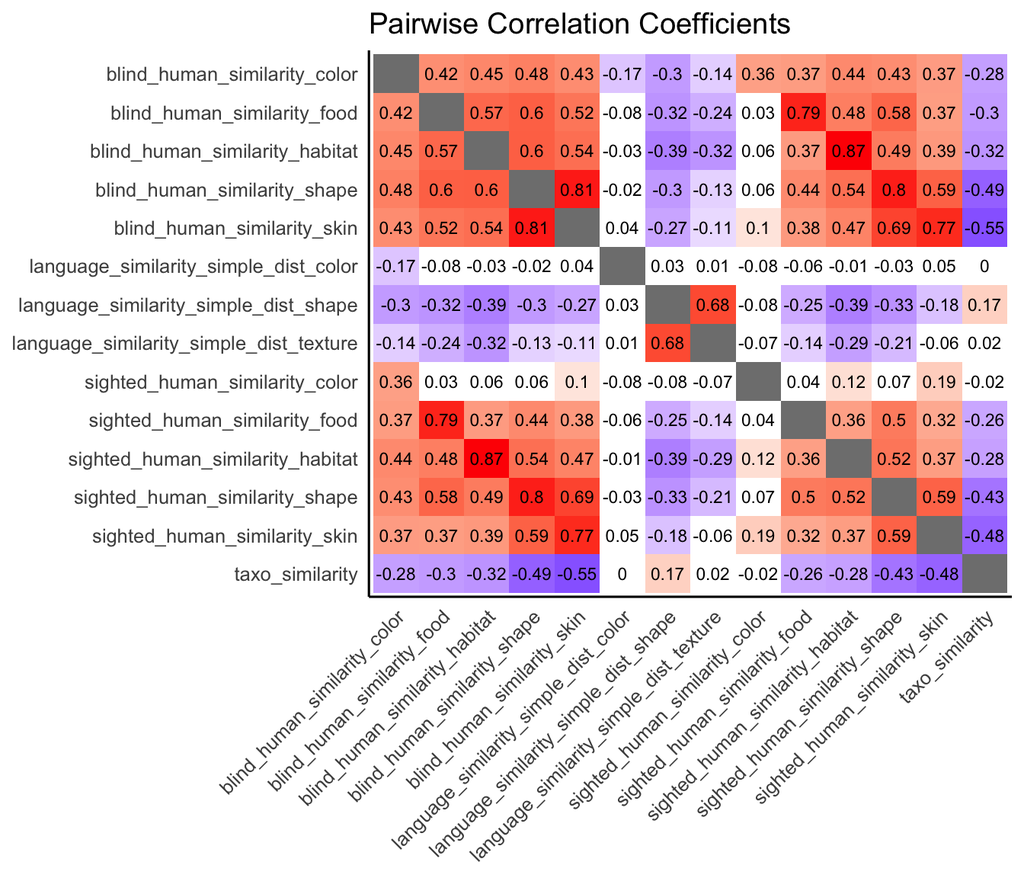

```r
plot_data <- full_sim_data_wide %>%
  select_if(is.numeric)

long_corr <- cor(plot_data,
                 use = "pairwise.complete.obs") %>%
  as.data.frame() %>%
  rownames_to_column("v2") %>%
  gather("v1", "estimate", -v2)

long_p <- corrplot::cor.mtest(plot_data,
                              use = "pairwise.complete.obs")$p %>%
  as.data.frame(row.names = names(plot_data)) %>%
  do(setNames(.,names(plot_data))) %>%
  rownames_to_column("v2") %>%
  gather("v1", "p", -v2)

corr_df <- full_join(long_corr, long_p) %>%
  mutate(estimate_char = case_when(v1 == v2 ~ "",
                                   TRUE ~ as.character(round(estimate,2))),
         estimate = case_when(v1 == v2 ~ as.numeric(NA),
                              TRUE ~ estimate),
         estimate_color = case_when(p < .05 ~ estimate, TRUE ~ 0 ))

ggplot(corr_df, aes(v1, fct_rev(v2), fill = estimate_color)) +
  geom_tile() + #rectangles for each correlation
  #add actual correlation value in the rectangle
  geom_text(aes(label = estimate_char), size=3) +
  scale_fill_gradient2(low ="blue", mid = "white", high = "red",
                       midpoint = 0, space = "Lab", guide = "colourbar",
                       name = "Pearson's r") +
  ggtitle("Pairwise Correlation Coefficients") +
  theme_classic(base_size = 12) +
  theme(axis.text.x = element_text(angle = 45, hjust = 1), #, hjust = .95, vjust = .2),
        axis.title.x=element_blank(),
        axis.title.y=element_blank(),
        axis.ticks = element_blank(),
        legend.position = "none")
```

```r
lm(human_similarity_color~ language_similarity_simple_dist_color+participant_type +
    taxo_similarity  ,  data = full_sim_data_wide2 %>% mutate_if(is.numeric, scale)) %>%
  summary()
```

```
##
## Call:
## lm(formula = human_similarity_color ~ language_similarity_simple_dist_color +
##     participant_type + taxo_similarity, data = full_sim_data_wide2 %>%
##     mutate_if(is.numeric, scale))
##
## Residuals:
##     Min      1Q  Median      3Q     Max
## -1.2494 -0.6622 -0.2665  0.3644  4.1476
##
## Coefficients:
##                                       Estimate Std. Error t value Pr(>|t|)
## (Intercept)                            0.18756    0.04659   4.026 6.18e-05
## language_similarity_simple_dist_color -0.10725    0.03297  -3.253 0.001185
## participant_typesighted               -0.37512    0.06589  -5.693 1.71e-08
## taxo_similarity                       -0.11095    0.03297  -3.366 0.000798
##
## (Intercept)                           ***
## language_similarity_simple_dist_color **
## participant_typesighted               ***
## taxo_similarity                       ***
## ---
## Signif. codes:  0 '***' 0.001 '**' 0.01 '*' 0.05 '.' 0.1 ' ' 1
##
## Residual standard error: 0.9718 on 866 degrees of freedom
## Multiple R-squared:  0.05891,    Adjusted R-squared:  0.05565
## F-statistic: 18.07 on 3 and 866 DF,  p-value: 2.217e-11
```

```r
lm(human_similarity_color~language_similarity_simple_dist_color +participant_type *
    taxo_similarity  ,  data = full_sim_data_wide2 %>% mutate_if(is.numeric, scale)) %>%
  summary()
```

```
##
## Call:
## lm(formula = human_similarity_color ~ language_similarity_simple_dist_color +
##     participant_type * taxo_similarity, data = full_sim_data_wide2 %>%
##     mutate_if(is.numeric, scale))
##
## Residuals:
##     Min      1Q  Median      3Q     Max
## -1.1870 -0.6741 -0.2608  0.3347  4.2302
##
## Coefficients:
##                                         Estimate Std. Error t value
## (Intercept)                              0.18756    0.04643   4.040
## language_similarity_simple_dist_color   -0.10725    0.03285  -3.265
## participant_typesighted                 -0.37512    0.06566  -5.713
## taxo_similarity                         -0.19933    0.04645  -4.291
## participant_typesighted:taxo_similarity  0.17677    0.06569   2.691
##                                         Pr(>|t|)
## (Intercept)                             5.82e-05 ***
## language_similarity_simple_dist_color    0.00114 **
## participant_typesighted                 1.52e-08 ***
## taxo_similarity                         1.98e-05 ***
## participant_typesighted:taxo_similarity  0.00727 **
## ---
## Signif. codes:  0 '***' 0.001 '**' 0.01 '*' 0.05 '.' 0.1 ' ' 1
##
## Residual standard error: 0.9683 on 865 degrees of freedom
## Multiple R-squared:  0.06672,    Adjusted R-squared:  0.06241
## F-statistic: 15.46 on 4 and 865 DF,  p-value: 3.194e-12
```

```r
lm(human_similarity_color~language_similarity_simple_dist_color  +
    taxo_similarity  ,  data = full_sim_data_wide2 %>% mutate_if(is.numeric, scale) %>% filter(participant_type == "blind")) %>%
  summary()
```

```
##
## Call:
## lm(formula = human_similarity_color ~ language_similarity_simple_dist_color +
##     taxo_similarity, data = full_sim_data_wide2 %>% mutate_if(is.numeric,
##     scale) %>% filter(participant_type == "blind"))
##
## Residuals:
##      Min       1Q   Median       3Q      Max
## -1.19043 -0.48458 -0.06184  0.37166  3.15547
##
## Coefficients:
##                                       Estimate Std. Error t value Pr(>|t|)
## (Intercept)                            0.18756    0.03199   5.864 8.99e-09
## language_similarity_simple_dist_color -0.12045    0.03200  -3.764 0.000191
## taxo_similarity                       -0.19940    0.03200  -6.230 1.11e-09
##
## (Intercept)                           ***
## language_similarity_simple_dist_color ***
## taxo_similarity                       ***
## ---
## Signif. codes:  0 '***' 0.001 '**' 0.01 '*' 0.05 '.' 0.1 ' ' 1
##
## Residual standard error: 0.6671 on 432 degrees of freedom
## Multiple R-squared:  0.1088, Adjusted R-squared:  0.1047
## F-statistic: 26.38 on 2 and 432 DF,  p-value: 1.558e-11
```

```r
lm(human_similarity_color~language_similarity_simple_dist_color  +
    taxo_similarity  ,  data = full_sim_data_wide2 %>% mutate_if(is.numeric, scale) %>% filter(participant_type == "sighted")) %>%
  summary()
```

```
##
## Call:
## lm(formula = human_similarity_color ~ language_similarity_simple_dist_color +
##     taxo_similarity, data = full_sim_data_wide2 %>% mutate_if(is.numeric,
##     scale) %>% filter(participant_type == "sighted"))
##
## Residuals:
##     Min      1Q  Median      3Q     Max
## -1.0470 -0.7732 -0.4904  0.1773  4.2224
##
## Coefficients:
##                                       Estimate Std. Error t value Pr(>|t|)
## (Intercept)                           -0.18756    0.05737  -3.269  0.00117
## language_similarity_simple_dist_color -0.09404    0.05741  -1.638  0.10212
## taxo_similarity                       -0.02250    0.05741  -0.392  0.69534
##
## (Intercept)                           **
## language_similarity_simple_dist_color
## taxo_similarity
## ---
## Signif. codes:  0 '***' 0.001 '**' 0.01 '*' 0.05 '.' 0.1 ' ' 1
##
## Residual standard error: 1.197 on 432 degrees of freedom
## Multiple R-squared:  0.00651,    Adjusted R-squared:  0.001911
## F-statistic: 1.415 on 2 and 432 DF,  p-value: 0.2439
```

```r
lm(human_similarity_color~language_similarity_simple_dist_color  + language_similarity_simple_dist_shape +language_similarity_simple_dist_texture +
    taxo_similarity  ,  data = full_sim_data_wide2 %>% mutate_if(is.numeric, scale) %>% filter(participant_type == "blind")) %>%
  summary()
```

```
##
## Call:
## lm(formula = human_similarity_color ~ language_similarity_simple_dist_color +
##     language_similarity_simple_dist_shape + language_similarity_simple_dist_texture +
##     taxo_similarity, data = full_sim_data_wide2 %>% mutate_if(is.numeric,
##     scale) %>% filter(participant_type == "blind"))
##
## Residuals:
##      Min       1Q   Median       3Q      Max
## -1.25077 -0.47007 -0.07745  0.37848  2.97932
##
## Coefficients:
##                                         Estimate Std. Error t value
## (Intercept)                              0.18756    0.03089   6.071
## language_similarity_simple_dist_color   -0.11402    0.03093  -3.686
## language_similarity_simple_dist_shape   -0.20898    0.04293  -4.868
## language_similarity_simple_dist_texture  0.04550    0.04228   1.076
## taxo_similarity                         -0.16451    0.03165  -5.198
##                                         Pr(>|t|)
## (Intercept)                             2.79e-09 ***
## language_similarity_simple_dist_color   0.000257 ***
## language_similarity_simple_dist_shape   1.59e-06 ***
## language_similarity_simple_dist_texture 0.282481
## taxo_similarity                         3.11e-07 ***
## ---
## Signif. codes:  0 '***' 0.001 '**' 0.01 '*' 0.05 '.' 0.1 ' ' 1
##
## Residual standard error: 0.6443 on 430 degrees of freedom
## Multiple R-squared:  0.1725, Adjusted R-squared:  0.1649
## F-statistic: 22.42 on 4 and 430 DF,  p-value: < 2.2e-16
```

```r
lm(human_similarity_color~language_similarity_simple_dist_color  + language_similarity_simple_dist_shape +language_similarity_simple_dist_texture +
    taxo_similarity  ,  data = full_sim_data_wide2 %>% mutate_if(is.numeric, scale) %>% filter(participant_type == "sighted")) %>%
  summary()
```

```
##
## Call:
## lm(formula = human_similarity_color ~ language_similarity_simple_dist_color +
##     language_similarity_simple_dist_shape + language_similarity_simple_dist_texture +
##     taxo_similarity, data = full_sim_data_wide2 %>% mutate_if(is.numeric,
##     scale) %>% filter(participant_type == "sighted"))
##
## Residuals:
##     Min      1Q  Median      3Q     Max
## -1.1917 -0.7497 -0.5078  0.2066  4.3739
##
## Coefficients:
##                                          Estimate Std. Error t value
## (Intercept)                             -0.187560   0.057330  -3.272
## language_similarity_simple_dist_color   -0.091176   0.057403  -1.588
## language_similarity_simple_dist_shape   -0.075872   0.079673  -0.952
## language_similarity_simple_dist_texture -0.025238   0.078473  -0.322
## taxo_similarity                         -0.008953   0.058731  -0.152
##                                         Pr(>|t|)
## (Intercept)                              0.00116 **
## language_similarity_simple_dist_color    0.11295
## language_similarity_simple_dist_shape    0.34148
## language_similarity_simple_dist_texture  0.74791
## taxo_similarity                          0.87891
## ---
## Signif. codes:  0 '***' 0.001 '**' 0.01 '*' 0.05 '.' 0.1 ' ' 1
##
## Residual standard error: 1.196 on 430 degrees of freedom
## Multiple R-squared:  0.01264,    Adjusted R-squared:  0.003459
## F-statistic: 1.377 on 4 and 430 DF,  p-value: 0.2411
```

# Google News

```r
LANG_ANIMAL_DISTANCE_COLOR <- here("data/processed/animal_color_distances_language_google.csv")
LANG_ANIMAL_DISTANCE_SHAPE<- here("data/processed/animal_shape_distances_language_google.csv")
LANG_ANIMAL_DISTANCE_TEXTURE <- here("data/processed/animal_texture_distances_language_google.csv")

TIDY_HUMAN_PATH <- here("data/processed/tidy_human_data.csv")
language_data <- read_csv(LANG_ANIMAL_DISTANCE_COLOR) %>%
  left_join(read_csv(LANG_ANIMAL_DISTANCE_SHAPE), by  = c("animal1", "animal2")) %>%
  left_join(read_csv(LANG_ANIMAL_DISTANCE_TEXTURE),by  = c("animal1", "animal2")) %>%
  select(-contains("PCA"))
 # mutate(language_similarity_simple_dist = -language_similarity_simple_dist)

human_data <- read_csv(TIDY_HUMAN_PATH)
full_sim_data <- full_join(language_data, human_data, by = c("animal1", "animal2"))

human_data_wide <- human_data %>%
  unite("measure", c("participant_type", "similarity_type")) %>%
  spread(measure, human_similarity)
full_sim_data_wide <- full_join(language_data, human_data_wide,
                                by = c("animal1", "animal2"))   %>%full_join(taxonomic_long)  %>%
  filter(animal1 < animal2)

full_sim_data_wide2 <-  full_join(language_data, human_data,
                                  by = c("animal1", "animal2"))    %>%
    spread(similarity_type, human_similarity) %>%
  full_join(taxonomic_long) %>%
  filter(animal1 < animal2)
```

Each data point here is an animal pair

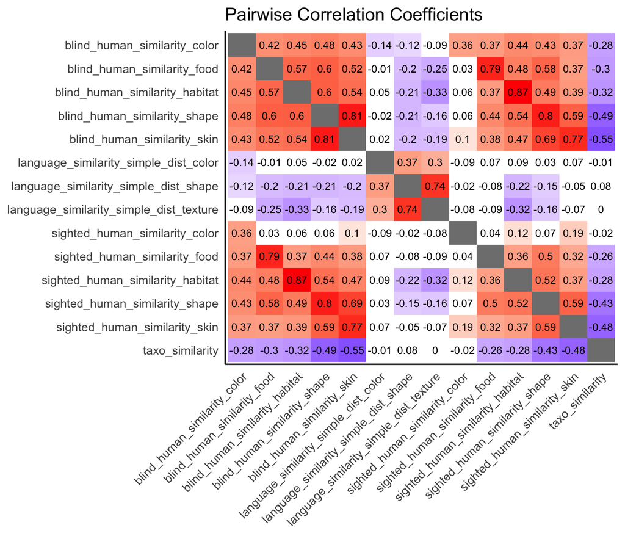

```r
plot_data <- full_sim_data_wide %>%
  select_if(is.numeric)

long_corr <- cor(plot_data,
                 use = "pairwise.complete.obs") %>%
  as.data.frame() %>%
  rownames_to_column("v2") %>%
  gather("v1", "estimate", -v2)

long_p <- corrplot::cor.mtest(plot_data,
                              use = "pairwise.complete.obs")$p %>%
  as.data.frame(row.names = names(plot_data)) %>%
  do(setNames(.,names(plot_data))) %>%
  rownames_to_column("v2") %>%
  gather("v1", "p", -v2)

corr_df <- full_join(long_corr, long_p) %>%
  mutate(estimate_char = case_when(v1 == v2 ~ "",
                                   TRUE ~ as.character(round(estimate,2))),
         estimate = case_when(v1 == v2 ~ as.numeric(NA),
                              TRUE ~ estimate),
         estimate_color = case_when(p < .05 ~ estimate, TRUE ~ 0 ))

ggplot(corr_df, aes(v1, fct_rev(v2), fill = estimate_color)) +
  geom_tile() + #rectangles for each correlation
  #add actual correlation value in the rectangle
  geom_text(aes(label = estimate_char), size=3) +
  scale_fill_gradient2(low ="blue", mid = "white", high = "red",
                       midpoint = 0, space = "Lab", guide = "colourbar",
                       name = "Pearson's r") +
  ggtitle("Pairwise Correlation Coefficients") +
  theme_classic(base_size = 12) +
  theme(axis.text.x = element_text(angle = 45, hjust = 1), #, hjust = .95, vjust = .2),
        axis.title.x=element_blank(),
        axis.title.y=element_blank(),
        axis.ticks = element_blank(),
        legend.position = "none")
```

```r
lm(human_similarity_color~ language_similarity_simple_dist_color+participant_type +
    taxo_similarity  ,  data = full_sim_data_wide2 %>% mutate_if(is.numeric, scale)) %>%
  summary()
```

```
##
## Call:
## lm(formula = human_similarity_color ~ language_similarity_simple_dist_color +
##     participant_type + taxo_similarity, data = full_sim_data_wide2 %>%
##     mutate_if(is.numeric, scale))
##
## Residuals:
##     Min      1Q  Median      3Q     Max
## -1.1824 -0.6535 -0.2698  0.3805  4.0856
##
## Coefficients:
##                                       Estimate Std. Error t value Pr(>|t|)
## (Intercept)                            0.18756    0.04662   4.023 6.24e-05
## language_similarity_simple_dist_color -0.10266    0.03298  -3.113  0.00192
## participant_typesighted               -0.37512    0.06593  -5.690 1.74e-08
## taxo_similarity                       -0.11098    0.03298  -3.365  0.00080
##
## (Intercept)                           ***
## language_similarity_simple_dist_color **
## participant_typesighted               ***
## taxo_similarity                       ***
## ---
## Signif. codes:  0 '***' 0.001 '**' 0.01 '*' 0.05 '.' 0.1 ' ' 1
##
## Residual standard error: 0.9723 on 866 degrees of freedom
## Multiple R-squared:  0.05795,    Adjusted R-squared:  0.05469
## F-statistic: 17.76 on 3 and 866 DF,  p-value: 3.424e-11
```